# The most harmful climate events to economic and human health

Giuliano Filippini

17/8/2014

### Synopsis

This report brings the most harmful climate events to the U.S. economy and to the people. Since climate change over the years, the scope on this resport was reduced to the years of 2001 to 2011 and brings which events caused more losses on the country. By the graphs is posible to evaluate that Tornados is the more concerning event with 15.000 people impacted (3 times the 2nd event), and with US$20 Billion on economic losses (4th on the ranking). The information was obteined from a dataset from the National Weather Service (NWS) of the National Ocean and Atmospheric Administration (NOAA) and the analysis was conduced in R programing language.

### Data Preparation & Data Information

```r
## this function downloads and unzips the file

read_stormdata <- function(url,nameout){
    url1<-url
    download.file(url1,destfile=nameout)
    bunzip2(nameout)

}
```

#### About Storm Data

Storms and other severe weather events can cause both public health and economic problems for communities and municipalities. Many severe events can result in fatalities, injuries, and property damage, and preventing such outcomes to the extent possible is a key concern.

The U.S. National Oceanic and Atmospheric Administration’s (NOAA) database tracks characteristics of major storms and weather events in the United States, including when and where they occur, as well as estimates of any fatalities, injuries, and property damage.

The data set has 902.297 observations on 37 variables reporting various aspects on weather ocurrences across the United States since 1950. There are plenty of information based on date/time of the event; type of weather ocurrence; fatalities and injuries; amount on crop and property losses, among others. Further information coud be acessed on oficial documentation provided by the NOAA:

- National Weather Service [Storm Data Documentation](http://d396qusza40orc.cloudfront.net/repdata%2Fpeer2_doc%2Fpd01016005curr.pdf)
- National Climatic Data Center Storm Events [FAQ](http://d396qusza40orc.cloudfront.net/repdata%2Fpeer2_doc%2FNCDC%20Storm%20Events-FAQ%20Page.pdf)

#### Data Processing

##### 1. Reading the data

Among the variables on the original dataset the main interest is on variables that can measure human hazards and economic damage. The variables used in this study are:

- BGN_DATE: date of the ocurrence;
- EVTYPE: type of event;
- FATALITIES: number of fatalities;
- INJURIES: number of people injuried; *PROPDMG: value of property damage in US$;
- PRPDMGEXP: multiply the value on *PROPDMG*, vales are (K: thousands, M:million, B:billion, etc.);
- CROPDMG: value of crop damages in US$;
- CROPDMGEXP: multiply the valeu on *CORPDMG*, values are (K: thousands, M:million, B:billion, etc.).

Another point of interest is that the NOAA dataset have information since 1950. For this analysis will be evaluated the ocurrences on the last 10 years. Since the last year available on the present dataset is 2011, the database will be filtered on dates greater than 2001.

The following code reads and simplify the data:

```r
## The code reads stormdata and keeps only the variables of interest
data<-read.csv("stormdata.csv")
vars<-c("BGN_DATE","EVTYPE","FATALITIES","INJURIES","PROPDMG","PROPDMGEXP","CROPDMG","CROPDMGEXP")
data<-data[vars]
# creates a variable named "year" with the year on BGN_DATE
data$year<-as.numeric(format(as.Date(data$BGN_DATE,"%m/%d/%Y"),"%Y"))
# excludes all years before 2001
data<-data[data$year>=2001,]
```

##### 2. Creating new variables

Some variables were created for the analysis. To simplify, human hazards will be the sum of **INJURIES** and **FATALITIES** and economic damage will be the sum of **CROPDMG** and **PROPDMG**. Since economic damage have multiple factors, some preparation is needed to achive the correct values.

```r
## human hazards
data$human_inj<-data$INJURIES+data$FATALITIES
## factors to multiply economic losses
data$crop_mult<-ifelse(data$CROPDMGEXP=='K',3,ifelse(data$CROPDMGEXP=='M',6,ifelse(data$CROPDMGEXP=='B',9,0)))
data$prop_mult<-ifelse(data$PROPDMGEXP=='K',3,ifelse(data$PROPDMGEXP=='M',6,ifelse(data$PROPDMGEXP=='B',9,0)))
## calculating economic losses
data$prop_dmg<-data$PROPDMG*10^data$prop_mult+data$CROPDMG*10^data$crop_mult
## economic losses in millions
data$econ_dmg<-data$prop_dmg*10^(-6)
```

### Results

#### Harmful climate events to human health

```r
## prepare data for human losses
hh_dmg<-data.frame(tapply(data$human_inj, as.character(data$EVTYPE), sum,na.rm=T))
names(hh_dmg)<-"hh_dmg"
hh_dmg$type<-as.character(row.names(hh_dmg))
hh_dmg <- hh_dmg[order(-hh_dmg$hh_dmg),]
row.names(hh_dmg)<-NULL
## table with most frequent human losses
kable(hh_dmg[1:10,c(2,1)],format="markdown")
```

```
##
##
## |type              | hh_dmg|
## |:-----------------|------:|
## |TORNADO           |  15483|
## |EXCESSIVE HEAT    |   4098|
## |LIGHTNING         |   3036|
## |TSTM WIND         |   1570|
## |THUNDERSTORM WIND |   1530|
## |HEAT              |   1452|
## |FLASH FLOOD       |   1353|
## |HURRICANE/TYPHOON |   1339|
## |WILDFIRE          |    986|
## |HIGH WIND         |    667|
```

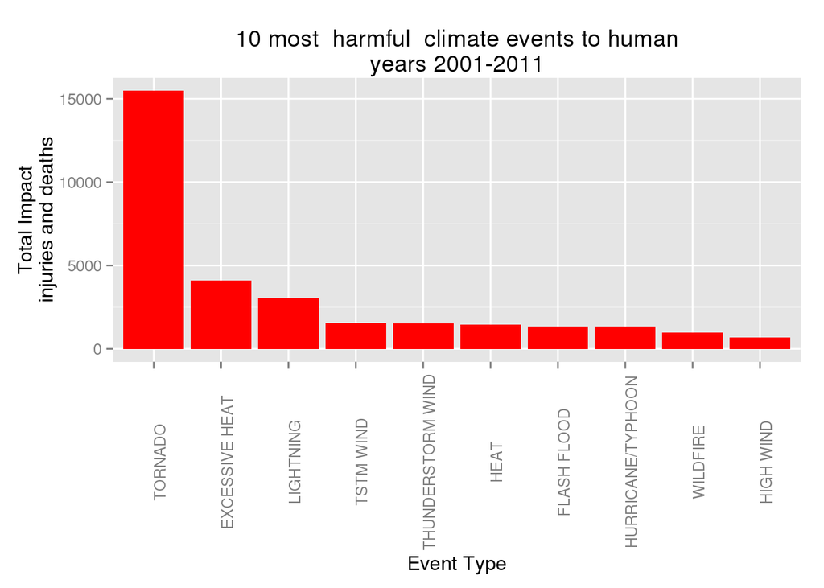

```r
## plot on the most harmfull events
plot_hh_dmg<-ggplot(data = hh_dmg[1:10, ], aes(x = reorder(type,-hh_dmg), y = hh_dmg)) + xlab("Event Type") + ylab("Total Impact\ninjuries and deaths")
plot_hh_dmg + geom_bar(fill = "red", stat = "identity") + theme(axis.text.x = element_text(angle = 90, hjust = 0.5, vjust = 1)) + ggtitle("10 most  harmful  climate events to human\nyears 2001-2011")
```

As can be seen from the table and the graph, the main cause on human harm is tornados with over than 15.000 casualties on the last 10 years. The second cause is excessive heat with less than 5.000.

#### Harmful climate events to the economy

```r
## prepare base to economic losses consolidate values on economic losses
ec_dmg<-data.frame(tapply(data$econ_dmg, as.character(data$EVTYPE), sum,na.rm=T))
names(ec_dmg)<-"ec_dmg"
ec_dmg$type<-as.character(row.names(ec_dmg))
ec_dmg <- ec_dmg[order(-ec_dmg$ec_dmg),]
row.names(ec_dmg)<-NULL
## makes the table for economic losses
kable(ec_dmg[1:10,c(2,1)],format="markdown",digits=2)
```

```
##
##
## |type              | ec_dmg|
## |:-----------------|------:|
## |FLOOD             | 137584|
## |HURRICANE/TYPHOON |  71914|
## |STORM SURGE       |  43170|
## |TORNADO           |  19265|
## |HAIL              |  13203|
## |FLASH FLOOD       |  12179|
## |TROPICAL STORM    |   7607|
## |DROUGHT           |   7543|
## |HIGH WIND         |   5395|
## |WILDFIRE          |   5054|
```

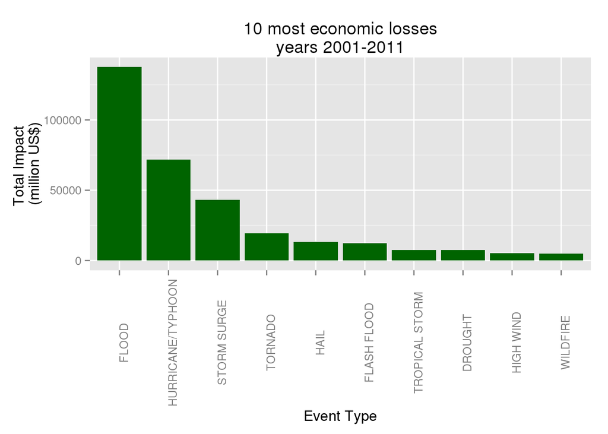

```r
## plot on economic losses
plot_ec_dmg<-ggplot(data = ec_dmg[1:10, ], aes(x = reorder(type,-ec_dmg), y = ec_dmg)) + xlab("Event Type") + ylab("Total Impact \n(million US$)")
plot_ec_dmg + geom_bar(fill = "darkgreen", stat = "identity") + theme(axis.text.x = element_text(angle = 90, hjust = 0.5, vjust = 1)) + ggtitle("10 most economic losses\nyears 2001-2011")
```

From the economic losses, Flood causes more impact with prejudice of US$ 137,5 Billion on the last 10 years. Hurricane/Typhoon causes almost US$72 Billion. Tornados is the 4th main cause on economic losses with almost US$20 Billion of prejudice. The graph shows the 10 most important economic losses on the last 10 years.